# Practical Machine Learning: Prediction Assignment Writeup

George Xiao

Sunday, Feb 28, 2016

## Summary

This is a writeup for the assignment of Coursera course “Practical Machine Learning”. A large amount of people exercise data from accelerators were given in this project. The goal of this project is to predict the manner in which they did the exercise.

The training data for this project are available [here](https://d396qusza40orc.cloudfront.net/predmachlearn/pml-training.csv). The test data are available [here](https://d396qusza40orc.cloudfront.net/predmachlearn/pml-testing.csv). More information is available from the website [here](http://groupware.les.inf.puc-rio.br/har) (see the section on the Weight Lifting Exercise Dataset).

## Data Processing

In this section, I describe (in words and codes) how the data were loaded into R and pre-processed for analysis.

#### Global Settings

Firstly, let’s set up the environment for the R markdown file

```r
knitr::opts_chunk$set(fig.width = 10, fig.height = 10, fig.path = 'Figs/',
                      echo = TRUE, warning = FALSE, message = FALSE)
library(caret)
library(ggplot2)
library(randomForest)
library(doParallel)
```

#### Load Data

The next thing is to load the raw data and take a quick look of them. *Note*, you need to set working directory to the same folder with the data file

```r
if(file.exists("pml-training.csv"))
    trainData <- read.csv("pml-training.csv", header = T)
if(file.exists("pml-testing.csv"))
    testData <- read.csv("pml-testing.csv", header = T)

dim(trainData)
```

```
## [1] 19622   160
```

```r
dim(testData)
```

```
## [1]  20 160
```

#### Clean Data

Now with the raw data, let’s pre-process it before feeding it to our model. Obviously, we can start with removing the columns with all `NA` and empty value.

```r
trainData.clean0 <- trainData[ , colSums(is.na(trainData)) == 0]                # Remove columns with only NA
trainData.clean1 <- trainData.clean0[, colSums(trainData.clean0 == '') == 0]    # Remove columns with no value
```

Then we can also remove the first seven columns. These are users’ information and timestamp which have nothing to do with our study.

```r
trainData.clean2 <- trainData.clean1[ , -(1:7)]
```

Finally, we have a clean data set with only 53 columns:

```r
dim(trainData.clean2)
```

```
## [1] 19622    53
```

## Model Fitting

In this section, after we have a clean dataset, let’s create a forecast model.

#### Split data for cross validation

Here I am spiting the data into 70% for training and 30% for testing.

```r
set.seed(1552)
inTrain <- createDataPartition(trainData.clean2$classe, p = 0.7, list = F)
training <- trainData.clean2[inTrain, ]
testing <- trainData.clean2[-inTrain, ]
```

#### Random Forest

In this study, I am choosing the `Random Forest` algorithm. Two reasons to pick this algorithm: 1) RF is harder to overfit; 2) RF is very robust.

Here I am using the help from library `doParallel` to speed up the model fitting process.

```r
registerDoParallel(cores = 4)   # use 4 cores for parallel execution

set.seed(1631)
rfModel <- randomForest(classe ~ ., data = training, ntree = 250, importance = T)
rfModel
```

```
##
## Call:
##  randomForest(formula = classe ~ ., data = training, ntree = 250,      importance = T)
##                Type of random forest: classification
##                      Number of trees: 250
## No. of variables tried at each split: 7
##
##         OOB estimate of  error rate: 0.62%
## Confusion matrix:
##      A    B    C    D    E class.error
## A 3902    2    0    1    1 0.001024066
## B   21 2631    6    0    0 0.010158014
## C    0   15 2379    2    0 0.007095159
## D    0    0   31 2221    0 0.013765542
## E    0    0    3    3 2519 0.002376238
```

Below please find the importance rank for all variables based on our model:

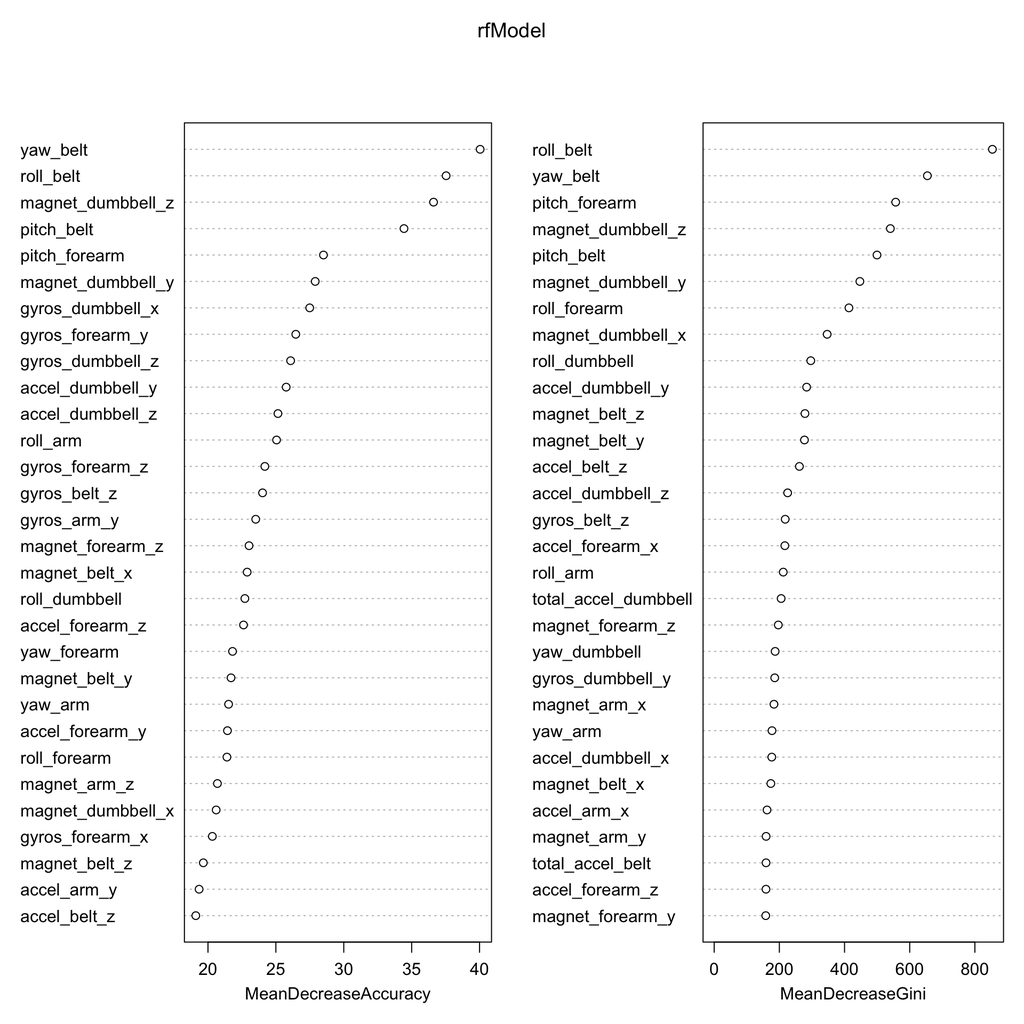

```r
varImpPlot(rfModel)
```

Lastly, with the model, let’s evaluate it on the testing data set:

```r
prediction <- predict(rfModel, testing)
confusionMatrix(prediction, testing$classe)
```

```
## Confusion Matrix and Statistics
##
##           Reference
## Prediction    A    B    C    D    E
##          A 1674    5    0    0    0
##          B    0 1134   10    0    0
##          C    0    0 1016   10    2
##          D    0    0    0  952    2
##          E    0    0    0    2 1078
##
## Overall Statistics
##
##                Accuracy : 0.9947
##                  95% CI : (0.9925, 0.9964)
##     No Information Rate : 0.2845
##     P-Value [Acc > NIR] : < 2.2e-16
##
##                   Kappa : 0.9933
##  Mcnemar's Test P-Value : NA
##
## Statistics by Class:
##
##                      Class: A Class: B Class: C Class: D Class: E
## Sensitivity            1.0000   0.9956   0.9903   0.9876   0.9963
## Specificity            0.9988   0.9979   0.9975   0.9996   0.9996
## Pos Pred Value         0.9970   0.9913   0.9883   0.9979   0.9981
## Neg Pred Value         1.0000   0.9989   0.9979   0.9976   0.9992
## Prevalence             0.2845   0.1935   0.1743   0.1638   0.1839
## Detection Rate         0.2845   0.1927   0.1726   0.1618   0.1832
## Detection Prevalence   0.2853   0.1944   0.1747   0.1621   0.1835
## Balanced Accuracy      0.9994   0.9968   0.9939   0.9936   0.9979
```

The accuracy on the testing data is 0.9947. We can safely conclude this model is a good fit.